# Getting Started with pep725

Matthias Templ[^1]

Barbara Templ[^2]

2026-04-23

*Vignette 1 of 4 for the **pep725** R package. The most current version is available on [GitHub](https://github.com/matthias-da/pep725) and [CRAN](https://CRAN.R-project.org/package=pep725).*

## What is Phenology?

Phenology is the study of cyclic and seasonal natural phenomena, especially in relation to climate and plant life cycles. In plant science, phenology focuses on the timing of recurring biological events such as:

- **Budburst**: When dormant buds begin to open in spring
- **Leaf unfolding**: The emergence of new leaves
- **Flowering**: When flowers open (anthesis)
- **Fruit ripening**: The maturation of fruits
- **Leaf senescence**: Autumn coloring and leaf fall

These phenological phases are strongly temperature-dependent and respond sensitively to interannual climate variability as well as long-term climate change. As a result, phenological records provide some of the most direct biological evidence of climate impacts on terrestrial ecosystems.

## The PEP725 Database

The [PEP725 Pan European Phenology Database](https://pep725.eu/) is one of the world’s most comprehensive collections of plant phenological observations. It brings together long-term records from national phenological monitoring networks across Europe into a harmonized and openly accessible research infrastructure. Key characteristics of PEP725 include (Templ et al. 2018, 2026):

- **Over 12 million observations** from across over 30 European countries
- **Records spanning 250+ years** (some stations have data back to the 1750s)
- **Thousands of monitoring stations** spanning a wide range of elevations
- **Broad taxonomic coverage** including agricultural crops, fruit trees, wild plant and forest tree species

Observations in PEP725 are based on standardized phase definitions (largely aligned with BBCH-type schemes) and consistent observation protocols within national networks. This standardization enables comparative analyses across regions, species, and time periods, thus addresses key data integration and reusability challenges commonly encountered in large, heterogeneous phenological datasets (Templ 2025).

## Why Use the pep725 R Package?

Working with phenological data presents several challenges:

1. **Data volume**: Millions of observations require efficient data handling
2. **Data quality**: Observations may contain errors or outliers
3. **Standardization**: Different countries use different formats
4. **Analysis complexity**: Calculating trends, normals, and anomalies requires specialized methods

The **pep725** package addresses these challenges by providing:

- Efficient data import and handling using `data.table`
- Quality assessment and outlier detection tools
- Functions for calculating phenological normals and anomalies
- Spatial analysis (gradients, synchrony)
- Publication-ready visualizations

## Installation

Before you begin, install the package:

```r
# Install from CRAN (when available)
install.packages("pep725")

# Or install development version from GitHub
# First install devtools if you don't have it:
# install.packages("devtools")
devtools::install_github("matthias-da/pep725")
```

## Loading the Package

Once installed, load the package at the start of your R session:

```r
library(pep725)
```

When the package loads, you’ll see a startup message with tips on how to get data.

## Getting Phenological Data

The **pep725** package offers five ways to obtain data. Understanding which option to use is important for your workflow:

| Option | Best For | Data Size | Internet Required? |
| --- | --- | --- | --- |
| **1. Download synthetic data** | Learning, tutorials, reproducible examples | ~7.24M rows | First download only |
| **2. Seed dataset** | Quick offline tests, minimal examples | ~1,300 rows | No |
| **3. Generate synthetic data** | Creating shareable versions of your data | Variable | No |
| **4. Import real PEP725 data** | Actual research and publications | ~7.24M rows | For initial download |
| **5. Use your own phenological data** | Regional networks, field trials, citizen science datasets | Variable | No |

### Why Synthetic Data?

You might wonder why we use synthetic data instead of real observations. The original PEP725 database has usage restrictions that prevent redistribution - you must register on the pep725.eu website and accept the data use policy. This creates a problem for tutorials and examples that need to be reproducible.

**Synthetic data** solves this problem. It is generated to preserve the statistical properties of real data:

- Same distributions of phenological events across seasons
- Similar correlations between variables (e.g. latitude and flowering date)
- Realistic spatial patterns across Europe
- Comparable year-to-year variability

This means you can learn all the analysis techniques using synthetic data, then apply them confidently to real data when you’re ready for actual research.

### Option 1: Download Synthetic Data (Recommended for Learning)

To learn the package, download the pre-generated synthetic dataset:

```r
# Download synthetic data (cached locally after first download)
pep <- pep_download()
```

You can check your cache status or clear it if needed:

```r
# Check cache status - shows file location and size
pep_cache_info()
```

```
#> $path
#> [1] "/Users/matthias/Library/Caches/org.R-project.R/R/pep725/pep_synth.rda"
#>
#> $size_mb
#> [1] 111.41
#>
#> $modified
#> [1] "2026-03-04 15:00:46 CET"
#>
#> $exists
#> [1] TRUE
```

```r
# If you need to clear the cache (e.g., to get an updated version):
# pep_cache_clear()
```

### Option 2: Use the Small Seed Dataset

For quick tests when you don’t need the full dataset, use the included seed data:

```r
# Load the included seed dataset (small, for quick tests only)
data(pep_seed)

# This is a small subset (~1,300 rows) useful for:
# - Testing code quickly
# - Working offline
# - Running examples in documentation
```

**When to use this**: If you’re developing code and want fast iteration without waiting for the full dataset to load, the seed dataset is perfect. However, it’s too small for meaningful statistical analyses.

### Option 3: Generate Your Own Synthetic Data

If you have real PEP725 data and want to create a shareable synthetic version (e.g., for teaching or supplementary materials), use `pep_simulate()`:

```r
# Generate synthetic data based on your real data
# This preserves statistical properties while anonymizing observations
pep_synthetic <- pep_simulate(your_real_pep_data)

# You can then share pep_synthetic freely
```

**Use case**: You’ve done an analysis with real data for a paper, and you want to provide reproducible examples in supplementary materials without violating data sharing restrictions.

### Option 4: Import Real PEP725 Data (For Research)

For actual research and publications, you’ll want real data. Here’s the process:

1. **Register** at [pep725.eu](https://pep725.eu/) (free for research)
2. **Download** data for your species/regions of interest
3. **Import** using `pep_import()`

```r
# Import from downloaded PEP725 files
# Point to the folder containing your downloaded CSV files
pep <- pep_import("path/to/pep725_data/")
```

The `pep_import()` function automatically cleans and formats the data:

- Converts columns to appropriate types (factors, dates, etc.)
- Handles missing values (e.g., -9999 altitude codes become NA)
- Removes problematic columns
- Optionally adds country names based on coordinates

### Option 5: Use Your Own Plant Phenological Data

Although **pep725** is designed around the structure and conventions of the PEP725 database, it is not limited to PEP725 data.

If your dataset consists of station-based phenological observations with:

- spatial coordinates (longitude and latitude),
- observation year,
- species identifiers,
- phenophase identifiers,
- and day-of-year (DOY) information,

you can use most of the functionality in **pep725** with minimal adaptation.

The key requirement is a *PEP725-like tabular structure* — one row per observation. This structure can usually be achieved with straightforward preprocessing (e.g., renaming columns and ensuring consistent DOY formatting).

Once your data has the required columns, convert it to a `pep` object:

```r
# Prepare your data with the required columns
my_data <- data.frame(
  s_id = c("MY001", "MY001", "MY002"),
  lon = c(10.1, 10.1, 11.3),
  lat = c(47.5, 47.5, 48.1),
  genus = c("Malus", "Malus", "Malus"),
  species = c("Malus domestica", "Malus domestica", "Malus domestica"),
  phase_id = c(60, 65, 60),
  year = c(2020, 2020, 2020),
  day = c(110, 125, 108)
)

# Convert to a pep object — validates required columns automatically
my_pep <- as.pep(my_data)
```

> **Important Note for Research**

> All examples in these vignettes use **synthetic data**. The patterns you see are realistic but not actual scientific observations.

> **For publishable research, always use real PEP725 data!** After registering at [pep725.eu](https://pep725.eu/), simply replace `pep_download()` with `pep_import("your/data/path/")`. All the analysis techniques work identically.

## Understanding the Data Structure

Now that we have data loaded, let’s understand what we’re working with. The `pep` object is a special type of data frame optimized for large datasets.

```r
# View the data - the print method shows a summary
print(pep)
```

```
#> PEP725 Phenological Data
#> --------------------------------------------------
#> Observations: 7,240,883
#> Stations:     10,927
#> Species:      41
#> Phases:       73 (BBCH codes: 0, 1, 3, 7, 9, ...)
#> Years:        1775 - 2025
#> Extent:       lon [-10.24, 48.35], lat [14.44, 68.44]
#> Countries:    34 (Austria, Belgium, Bosnia and Herz., Bulgaria, Croatia, ...)
#> --------------------------------------------------
#> First 5 rows:
#>      s_id     lon     lat  genus        species phase_id  year   day
#>    <fctr>   <num>   <num> <fctr>         <fctr>    <int> <int> <int>
#> 1:  26675 16.3264 48.3036  Vitis Vitis vinifera      100  1775   297
#> 2:  26675 16.3264 48.3036  Vitis Vitis vinifera      100  1776   281
#> 3:  26675 16.3264 48.3036  Vitis Vitis vinifera      100  1777   288
#> 4:  26675 16.3264 48.3036  Vitis Vitis vinifera      100  1778   290
#> 5:  26675 16.3264 48.3036  Vitis Vitis vinifera      100  1779   288
```

Let’s get a quick visual overview. The `plot()` method for `pep` objects provides three built-in views — a station map, a time series, and a DOY histogram:

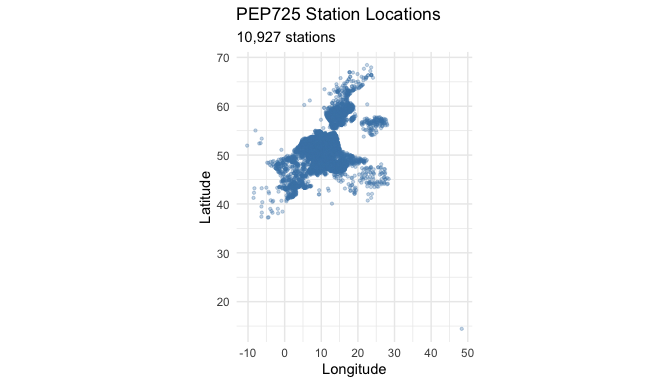

```r
# Where are the stations?
plot(pep, type = "map")
```

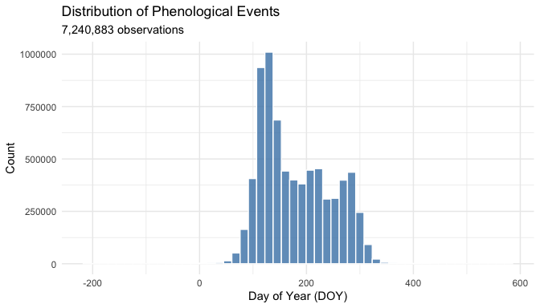

```r
# How are phenological events distributed across the year?
plot(pep, type = "histogram")
```

### What You See in the Output

The output shows you:

- **Dimensions**: Number of rows (observations) and columns
- **Column names and types**: What variables are available
- **First few rows**: A preview of actual values

### Key Columns Explained

Each row in the dataset represents **one phenological observation** - a record of when a specific plant at a specific location reached a particular developmental stage.

| Column | Description | Example |
| --- | --- | --- |
| `s_id` | **Station identifier** - A unique code for each monitoring location | “AT0001” |
| `lon`, `lat` | **Geographic coordinates** - Longitude and latitude in decimal degrees | 15.5, 48.2 |
| `alt` | **Altitude** - Elevation above sea level in meters | 350 |
| `genus` | **Plant genus** - The genus name (first part of scientific name) | “Malus” |
| `species` | **Full species name** - Genus + specific epithet | “Malus domestica” |
| `phase_id` | **BBCH code** - Standardized phenological stage (explained below) | 60 |
| `year` | **Observation year** | 2015 |
| `day` | **Day of year (DOY)** - The day when the phase was observed (1-365) | 145 |
| `country` | **Country name** | “Austria” |

### Understanding Day of Year (DOY)

Phenological data uses **Day of Year (DOY)** rather than calendar dates. This simplifies calculations and comparisons:

- DOY 1 = January 1
- DOY 91 = April 1 (approximately)
- DOY 182 = July 1 (approximately)
- DOY 274 = October 1 (approximately)
- DOY 365/366 = December 31

**Why DOY?** It makes it easy to calculate things like “flowering advanced by 10 days” without dealing with month boundaries.

## The `pep` Class

The package provides a custom class system that extends `data.table` with phenology-specific methods. Let’s verify what class our data has:

```r
# Check the class hierarchy
class(pep)
```

```
#> [1] "pep"        "data.table" "data.frame"
```

You’ll see three classes:

1. `pep` - Our custom class with phenology-specific methods
2. `data.table` - Fast data manipulation (from the data.table package)
3. `data.frame` - Base R compatibility

This means you can use:

- **pep725 functions** designed for phenological analysis
- **data.table syntax** for fast filtering and aggregation
- **Base R functions** that work with data frames

### The Summary Method

The `summary()` function is your first tool for understanding a phenological dataset. It provides different views depending on the `by` parameter:

```r
# Default summary - shows top species by observation count
summary(pep)
```

```
#> PEP725 Phenological Data Summary
#> ==================================================
#>
#> OVERVIEW
#>   Total observations: 7,240,883
#>   Unique stations:    10,927
#>   Year range:         1775 - 2025
#>   DOY range:          -210 - 578
#>
#> TOP 10 SPECIES (by observation count)
#>        genus           species  n_obs n_stations year_min year_max median_doy
#>       <fctr>            <fctr>  <int>      <int>    <int>    <int>      <int>
#>  1:  Hordeum   Hordeum vulgare 930924       7996     1870     2025        175
#>  2:    Malus   Malus domestica 899311       8403     1896     2025        140
#>  3: Triticum Triticum aestivum 668330       7504     1870     2024        220
#>  4:    Avena      Avena sativa 642098       7737     1870     2025        150
#>  5:   Secale    Secale cereale 605981       7837     1870     2025        213
#>  6:  Solanum Solanum tuberosum 593638       7866     1870     2025        176
#>  7:   Prunus    Prunus cerasus 483615       7083     1873     2025        130
#>  8:   Prunus  Prunus domestica 429971       7617     1868     2025        134
#>  9:      Zea          Zea mays 417009       5692     1941     2025        193
#> 10:     Beta     Beta vulgaris 403413       6219     1926     2024        130
```

**What this tells you**: Which species have the most data, how many stations observe each species, and the year range of observations.

```r
# Summary by phenological phase
summary(pep, by = "phase")
```

```
#> PEP725 Phenological Data Summary
#> ==================================================
#>
#> OVERVIEW
#>   Total observations: 7,240,883
#>   Unique stations:    10,927
#>   Year range:         1775 - 2025
#>   DOY range:          -210 - 578
#>
#> OBSERVATIONS BY BBCH PHASE
#>     phase_id                                 phase_name  n_obs n_species
#>        <int>                                     <char>  <int>     <int>
#>  1:        0                        Dry seed / Dormancy 751405        21
#>  2:        1                            Seed imbibition  18041         8
#>  3:        3                                      Other   1099         6
```

[output cut: 149 more lines]

**What this tells you**: Which developmental stages are recorded, how many observations of each, and the typical DOY (useful for understanding the seasonal distribution of your data).

```r
# Summary by country (showing top 5)
summary(pep, by = "country", top = 5)
```

```
#> PEP725 Phenological Data Summary
#> ==================================================
#>
#> OVERVIEW
#>   Total observations: 7,240,883
#>   Unique stations:    10,927
#>   Year range:         1775 - 2025
#>   DOY range:          -210 - 578
#>
#> TOP 5 COUNTRIES (by observation count)
#>          country   n_obs n_stations n_species year_min year_max
#>           <char>   <int>      <int>     <int>    <int>    <int>
#> 1: Germany-North 4181984       4685        17     1951     2023
#> 2: Germany-South 2333531       1987        18     1930     2023
#> 3:       Austria  366048       1434        22     1775     2025
#> 4:        Sweden   82331        908        22     1870     2024
#> 5:      Slovakia   53052         76        15     1950     2024
```

**What this tells you**: Geographic coverage - which countries contribute most data, how many stations they have, and species diversity.

```r
# Temporal coverage summary
summary(pep, by = "year")
```

```
#> PEP725 Phenological Data Summary
#> ==================================================
#>
#> OVERVIEW
#>   Total observations: 7,240,883
#>   Unique stations:    10,927
#>   Year range:         1775 - 2025
#>   DOY range:          -210 - 578
#>
#> TEMPORAL COVERAGE
#>   Years with data:    247
#>   Median obs/year:    1,243
#>   Peak year:          1968 (151,997 obs)
#>
#>   Last 10 years:
#>      year n_obs n_stations n_species
#>     <int> <int>      <int>     <int>
#>  1:  2016 47812       1654        32
#>  2:  2017 43068       1571        29
#>  3:  2018 41041       1536        33
#>  4:  2019 42209       1522        29
#>  5:  2020 40181       1500        32
#>  6:  2021 39085       1393        31
#>  7:  2022 36813       1376        28
#>  8:  2023 35133       1351        28
#>  9:  2024  4315        369        27
#> 10:  2025   649         85        19
```

**What this tells you**: How observations are distributed across years - are there gaps? Is coverage increasing or decreasing over time?

### Subsetting the Data

You’ll often want to focus on specific subsets of the data. The package preserves the `pep` class when you subset, so all methods continue to work:

```r
# Filter to apple data using data.table syntax
# The syntax is: dataset[row_filter, column_selection]
apple <- pep[species == "Malus domestica"]
print(apple)
```

```
#> PEP725 Phenological Data
#> --------------------------------------------------
#> Observations: 899,311
#> Stations:     8,403
#> Species:      1
#> Phases:       31 (BBCH codes: 0, 7, 10, 11, 15, ...)
#> Years:        1896 - 2025
#> Extent:       lon [-8.37, 48.35], lat [14.44, 66.90]
#> Countries:    24 (Austria, Bosnia and Herz., Croatia, Czechia, France, ...)
#> --------------------------------------------------
#> First 5 rows:
#>      s_id   lon   lat  genus         species phase_id  year   day
#>    <fctr> <num> <num> <fctr>          <fctr>    <int> <int> <int>
#> 1:  29529  2.49  48.8  Malus Malus domestica       65  1896   103
#> 2:  29529  2.49  48.8  Malus Malus domestica       65  1897   118
#> 3:  29529  2.49  48.8  Malus Malus domestica       65  1898   118
#> 4:  29529  2.49  48.8  Malus Malus domestica       65  1900   130
#> 5:  29529  2.49  48.8  Malus Malus domestica       65  1901   116
```

```r
# Filter by year range
recent <- pep[year >= 2000 & year <= 2015]
print(recent)
```

```
#> PEP725 Phenological Data
#> --------------------------------------------------
#> Observations: 985,849
#> Stations:     3,576
#> Species:      33
#> Phases:       56 (BBCH codes: 0, 3, 7, 9, 10, ...)
#> Years:        2000 - 2015
#> Extent:       lon [-10.24, 28.40], lat [37.22, 64.55]
#> Countries:    28 (Austria, Belgium, Bosnia and Herz., Bulgaria, Croatia, ...)
#> --------------------------------------------------
#> First 5 rows:
#>      s_id      lon     lat      genus        species phase_id  year   day
#>    <fctr>    <num>   <num>     <fctr>         <fctr>    <int> <int> <int>
#> 1:    136  9.18333 54.2500 perm_grass           <NA>      182  2000     5
#> 2:   6047 12.10000 50.8333 perm_grass           <NA>      182  2000     9
#> 3:   1304  7.10000 51.1000 perm_grass           <NA>      182  2000    10
#> 4:   6532 14.08330 47.4833     Secale Secale cereale        0  2000    15
#> 5:    206  9.66667 54.3167 perm_grass           <NA>      182  2000    17
```

```r
# The summary method works on subsets too
summary(recent)
```

```
#> PEP725 Phenological Data Summary
#> ==================================================
#>
#> OVERVIEW
#>   Total observations: 985,849
#>   Unique stations:    3,576
#>   Year range:         2000 - 2015
#>   DOY range:          -128 - 523
#>
#> TOP 10 SPECIES (by observation count)
#>          genus           species  n_obs n_stations year_min year_max median_doy
#>         <fctr>            <fctr>  <int>      <int>    <int>    <int>      <int>
#>  1:      Malus   Malus domestica 179208       2734     2000     2015        133
#>  2:        Zea          Zea mays 107126       1829     2000     2015        198
#>  3:    Hordeum   Hordeum vulgare  95636       1906     2000     2015        181
#>  4:   Triticum Triticum aestivum  90484       1848     2000     2015        207
#>  5:     Prunus      Prunus avium  86023       2820     2000     2015        122
#>  6:     Secale    Secale cereale  68568       1491     2000     2015        202
#>  7:      Avena      Avena sativa  67242       1558     2000     2015        150
#>  8:      Pyrus    Pyrus communis  65482       2063     2000     2015        121
#>  9:     Prunus    Prunus cerasus  61866       1835     2000     2015        123
#> 10: perm_grass              <NA>  50086       2328     2000     2015        135
```

**Tip for beginners**: The `data.table` syntax `pep[condition]` is similar to base R’s `subset()` function but much faster for large datasets. You can combine multiple conditions with `&` (and) or `|` (or).

## Understanding BBCH Codes

The **BBCH scale** [from Biologische Bundesanstalt, Bundessortenamt und CHemische Industrie; Meier (2018)] is a standardized system for describing plant developmental stages. It’s used worldwide, ensuring that “flowering” means the same thing whether observed in Germany or Spain.

### How BBCH Codes Work

BBCH codes are two-digit numbers where:

- The **first digit** (0-9) indicates the principal growth stage
- The **second digit** indicates the secondary stage within that principal stage

| First Digit | Principal Growth Stage |
| --- | --- |
| 0 | Germination / sprouting |
| 1 | Leaf development |
| 2 | Formation of side shoots / tillering |
| 3 | Stem elongation |
| 4 | Development of harvestable vegetative parts |
| 5 | Inflorescence emergence / heading |
| 6 | Flowering |
| 7 | Development of fruit |
| 8 | Ripening of fruit and seed |
| 9 | Senescence / dormancy |

### Looking Up BBCH Codes

The `bbch_description()` function translates codes to human-readable descriptions:

```r
# Get descriptions for BBCH codes present in your data
codes <- unique(pep$phase_id)
bbch_description(codes)
```

```
#>    phase_id                                description
#> 1         0                        Dry seed / Dormancy
#> 2         1                            Seed imbibition
#> 3         7                         Coleoptile emerged
#> 4         9                                  Emergence
#> 5        10              First leaf through coleoptile
#> 6        11                        First leaf unfolded
#> 7        12                          2 leaves unfolded
#> 8        13                          3 leaves unfolded
#> 9        15                                True leaves
#> 10       19                         9+ leaves unfolded
#> 11       21                     Beginning of tillering
#> 12       31                      First node detectable
#> 13       49                                  Late boot
#> 14       51                       Beginning of heading
```

[output cut: 21 more lines]

### Commonly Used BBCH Codes in Phenological Research

| Code | Stage | What to Look For |
| --- | --- | --- |
| 10 | First leaves | Cotyledons or first true leaves visible |
| 11 | First leaf unfolded | First true leaf fully unfolded |
| 60 | First flowers open | Beginning of flowering (anthesis) |
| 65 | Full flowering | 50% of flowers open |
| 69 | End of flowering | All petals fallen |
| 85 | Fruit coloring | Softening begins |
| 87 | Fruit ripe | Ready for harvest |
| 89 | Full ripeness | Fruit fully mature |
| 91 | Shoot growth complete | Leaves fully colored |
| 95 | Leaf fall | 50% of leaves fallen |

### Filtering by Phenological Phase

When analyzing phenology, you typically focus on specific phenophases. Here’s how:

```r
# Get all flowering observations (BBCH 60-69)
flowering <- pep[phase_id >= 60 & phase_id <= 69]
cat("Flowering observations:", nrow(flowering), "\n")
```

```
#> Flowering observations: 1833933
```

```r
# Get only full flowering (BBCH 65)
full_flowering <- pep[phase_id == 65]
cat("Full flowering observations:", nrow(full_flowering), "\n")
```

```
#> Full flowering observations: 475922
```

```r
# Get harvest-related observations
harvest <- pep[phase_id %in% c(87, 89)]
cat("Harvest observations:", nrow(harvest), "\n")
```

```
#> Harvest observations: 910185
```

## Exploring Data Coverage

Before diving into analysis, it’s crucial to understand what your dataset contains. The `pep_coverage()` function provides a comprehensive overview.

### Full Coverage Report

```r
# Get a complete coverage report
pep_coverage(pep)
```

```
#> PEP725 Data Coverage Report
#> ==================================================
#>
#> TEMPORAL COVERAGE
#> ------------------------------
#>   Year range:      1775 - 2025 (247 years)
#>   Missing years:   4 gaps
#>                    (1786, 1805, 1820, 1829)
#>   Median obs/year: 1,243
#>   Peak year:       1968 (151,997 obs)
#>
#> GEOGRAPHICAL COVERAGE
#> ------------------------------
#>   Countries:       35
#>   Stations:        10,927
#>   Longitude:       -10.24 to 48.35
#>   Latitude:        14.44 to 68.44
#>   Altitude:        0 to 1933 m
#>
#>   Top countries:
#>           country   n_obs n_stations n_species
#>            <char>   <int>      <int>     <int>
#>  1: Germany-North 4181984       4685        17
#>  2: Germany-South 2333531       1987        18
#>  3:       Austria  366048       1434        22
#>  4:        Sweden   82331        908        22
#>  5:      Slovakia   53052         76        15
#>  6:   Switzerland   51620        186        19
#>  7:          <NA>   32117         98        22
#>  8:        France   20487        706        22
#>  9:       Croatia   20130         10        15
#> 10:       Czechia   20008        146        14
#>
#> SPECIES COVERAGE
#> ------------------------------
#>   Genera:          30
#>   Species:         41
#>   Subspecies:      129
#>
#>   Top genera:
```

[output cut: 11 more lines]

```
#> 10:    Pyrus  308320         1       7749
#>
#>   Top species:
#>        genus           species  n_obs n_stations year_min year_max
#>       <fctr>            <fctr>  <int>      <int>    <int>    <int>
#>  1:  Hordeum   Hordeum vulgare 930924       7996     1870     2025
#>  2:    Malus   Malus domestica 899311       8403     1896     2025
#>  3: Triticum Triticum aestivum 668330       7504     1870     2024
#>  4:    Avena      Avena sativa 642098       7737     1870     2025
#>  5:   Secale    Secale cereale 605981       7837     1870     2025
#>  6:  Solanum Solanum tuberosum 593638       7866     1870     2025
#>  7:   Prunus    Prunus cerasus 483615       7083     1873     2025
#>  8:   Prunus  Prunus domestica 429971       7617     1868     2025
#>  9:      Zea          Zea mays 417009       5692     1941     2025
#> 10:     Beta     Beta vulgaris 403413       6219     1926     2024
```

This report shows you three dimensions of coverage:

1. **Temporal**: What years are covered? Any gaps?
2. **Geographical**: Which countries/regions? How many stations?
3. **Species**: Which plants are observed? How many observations each?

### Focused Coverage Analysis

You can focus on specific aspects and optionally generate plots:

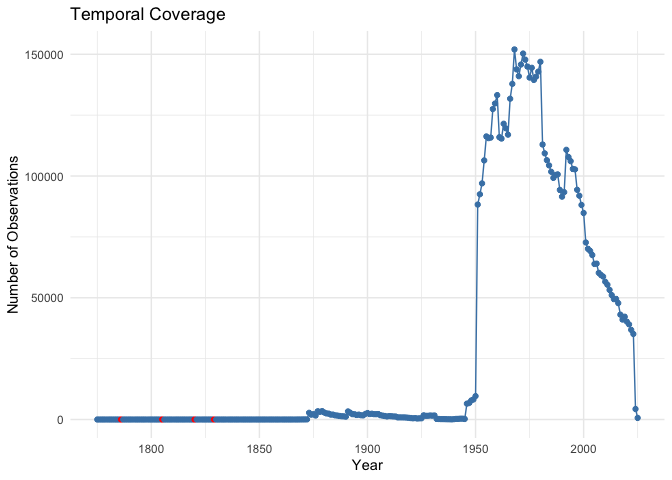

```
#> PEP725 Data Coverage Report
#> ==================================================
#>
#> TEMPORAL COVERAGE
#> ------------------------------
#>   Year range:      1775 - 2025 (247 years)
#>   Missing years:   4 gaps
#>                    (1786, 1805, 1820, 1829)
#>   Median obs/year: 1,243
#>   Peak year:       1968 (151,997 obs)
```

```r
# Temporal coverage with a visualization
pep_coverage(pep, kind = "temporal", plot = TRUE)
```

The temporal plot shows observation density over time. Look for:

- **Gaps**: Years with few or no observations
- **Trends**: Is data coverage increasing or decreasing over time?
- **Breakpoints**: Sudden changes (e.g. due to methodology changes)

```r
# Geographical coverage - which countries have most data
pep_coverage(pep, kind = "geographical", top = 5)
```

```
#> PEP725 Data Coverage Report
#> ==================================================
#>
#> GEOGRAPHICAL COVERAGE
#> ------------------------------
#>   Countries:       35
#>   Stations:        10,927
#>   Longitude:       -10.24 to 48.35
#>   Latitude:        14.44 to 68.44
#>   Altitude:        0 to 1933 m
#>
#>   Top countries:
#>          country   n_obs n_stations n_species
#>           <char>   <int>      <int>     <int>
#> 1: Germany-North 4181984       4685        17
#> 2: Germany-South 2333531       1987        18
#> 3:       Austria  366048       1434        22
#> 4:        Sweden   82331        908        22
#> 5:      Slovakia   53052         76        15
```

Geographic coverage tells you where your data comes from. This is important because:

- Different regions have different climates
- Some countries have longer observation histories
- Network density affects spatial analyses

```r
# Species coverage - which species are best represented
pep_coverage(pep, kind = "species", top = 5)
```

```
#> PEP725 Data Coverage Report
#> ==================================================
#>
#> SPECIES COVERAGE
#> ------------------------------
#>   Genera:          30
#>   Species:         41
#>   Subspecies:      129
#>
#>   Top genera:
#>       genus   n_obs n_species n_stations
#>      <fctr>   <int>     <int>      <int>
#> 1:   Prunus 1357252         7      10012
#> 2:  Hordeum  930924         1       7996
#> 3:    Malus  899311         1       8403
#> 4: Triticum  668330         1       7504
#> 5:    Avena  642098         1       7737
#>
#>   Top species:
#>       genus           species  n_obs n_stations year_min year_max
#>      <fctr>            <fctr>  <int>      <int>    <int>    <int>
#> 1:  Hordeum   Hordeum vulgare 930924       7996     1870     2025
#> 2:    Malus   Malus domestica 899311       8403     1896     2025
#> 3: Triticum Triticum aestivum 668330       7504     1870     2024
#> 4:    Avena      Avena sativa 642098       7737     1870     2025
#> 5:   Secale    Secale cereale 605981       7837     1870     2025
```

Species coverage shows which plants have enough data for robust analyses. As a rule of thumb:

- **>10,000 observations**: Excellent for most analyses
- **1,000-10,000 observations**: Good for national/regional analyses
- **<1,000 observations**: Limited; may need to combine with related species

### Coverage by Groups

You can break down coverage by grouping variables:

```r
# Temporal coverage broken down by country
cov_by_country <- pep_coverage(pep, kind = "temporal", by = "country")
# Show observations by group
cov_by_country$temporal$obs_by_group
```

```
#>              country   n_obs n_stations year_min year_max n_years
#>               <char>   <int>      <int>    <int>    <int>   <int>
#>  1:    Germany-North 4181984       4685     1951     2023      73
#>  2:    Germany-South 2333531       1987     1930     2023      80
#>  3:          Austria  366048       1434     1775     2025     193
#>  4:           Sweden   82331        908     1870     2024     115
#>  5:         Slovakia   53052         76     1950     2024      55
#>  6:      Switzerland   51620        186     1951     2024      74
#>  7:             <NA>   32117         98     1873     2025     121
#>  8:           France   20487        706     1872     2025     151
#>  9:          Croatia   20130         10     1961     2024      63
#> 10:          Czechia   20008        146     1930     2023      76
#> 11:         Slovenia   11507         15     1961     2020      60
#> 12:        Lithuania   11449         28     1960     2004      45
#> 13:           Poland    9461         14     1951     2024      74
```

[output cut: 24 more lines]

This helps identify which countries have continuous records versus sporadic observations.

## Your First Analysis: Tracking Flowering Trends

Let’s put everything together with a simple but meaningful analysis: tracking how apple flowering dates have changed over time.

```r
# Step 1: Filter to apple flowering (BBCH 60 = first flowers)
apple_flowering <- pep[species == "Malus domestica" & phase_id == 60]

cat("Apple flowering observations:", nrow(apple_flowering), "\n")
```

```
#> Apple flowering observations: 205403
```

```r
cat("Year range:", min(apple_flowering$year), "-", max(apple_flowering$year), "\n")
```

```
#> Year range: 1926 - 2025
```

```r
cat("Countries:", length(unique(apple_flowering$country)), "\n")
```

```
#> Countries: 24
```

```r
# Step 2: Calculate annual mean DOY
# The data.table syntax here means:
#   - Group by year
#   - Calculate mean DOY and count observations
#   - Order by year
annual_mean <- apple_flowering[, .(
  mean_doy = mean(day, na.rm = TRUE),
  n_obs = .N
), by = year][order(year)]

# Step 3: Look at the results
print(annual_mean)
```

```
#>       year mean_doy n_obs
#>      <int>    <num> <int>
#>   1:  1926 119.4658    73
#>   2:  1927 126.0164    61
#>   3:  1928 126.5750    80
#>   4:  1929 133.8764    89
#>   5:  1930 126.1333    90
#>   6:  1931 132.2447    94
#>   7:  1932 130.5000     2
#>   8:  1933 135.5000     2
#>   9:  1934 138.0000     2
#>  10:  1935 139.0000     1
#>  11:  1936 135.0000     1
#>  12:  1937 136.0000     1
#>  13:  1938 141.0000     1
```

[output cut: 89 more lines]

Now let’s visualize the trend:

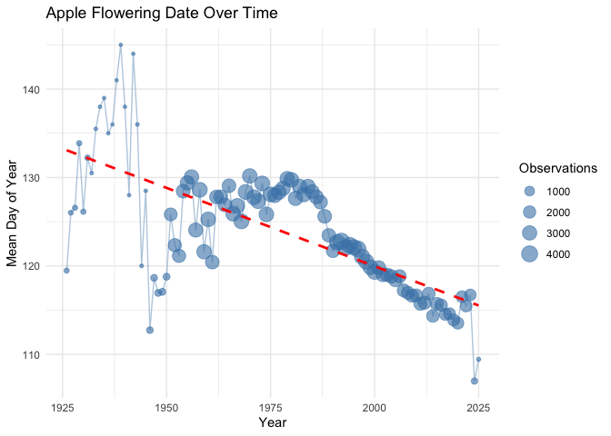

```r
# Step 4: Plot the trend with ggplot2
library(ggplot2)

p <- ggplot(annual_mean, aes(x = year, y = mean_doy)) +
  geom_point(aes(size = n_obs), color = "steelblue", alpha = 0.6) +
  geom_line(color = "steelblue", alpha = 0.4) +
  geom_smooth(method = "lm", color = "red", linetype = 2, se = FALSE) +
  labs(
    title = "Apple Flowering Date Over Time",
    x = "Year", y = "Mean Day of Year",
    size = "Observations"
  ) +
  theme_minimal()
print(p)
```

```r
# Step 5: Quantify the trend
trend <- lm(mean_doy ~ year, data = annual_mean)
slope <- coef(trend)[2]
cat("\nTrend:", round(slope * 10, 2), "days per decade\n")
```

```
#>
#> Trend: -1.77 days per decade
```

```r
if (slope < 0) {
  cat("Interpretation: Flowering is getting EARLIER\n")
} else {
  cat("Interpretation: Flowering is getting LATER\n")
}
```

```
#> Interpretation: Flowering is getting EARLIER
```

**Interpreting the results**: A negative slope means flowering is occurring earlier in the year - a common finding for spring phenology in a warming climate. A shift of -2 days per decade means that over 50 years, flowering has advanced by about 10 days.

### Comparing with Another Species: Grapevine

Let’s compare apple with grapevine (*Vitis vinifera*), which has the longest time series in the database (records back to 1775 in some regions):

```r
# Step 1: Filter to grapevine flowering (BBCH 65 = full flowering)
vine_flowering <- pep[species == "Vitis vinifera" & phase_id == 65]

cat("Grapevine flowering observations:", nrow(vine_flowering), "\n")
```

```
#> Grapevine flowering observations: 17749
```

```r
cat("Year range:", min(vine_flowering$year), "-", max(vine_flowering$year), "\n")
```

```
#> Year range: 1951 - 2024
```

```r
cat("Countries:", length(unique(vine_flowering$country)), "\n")
```

```
#> Countries: 15
```

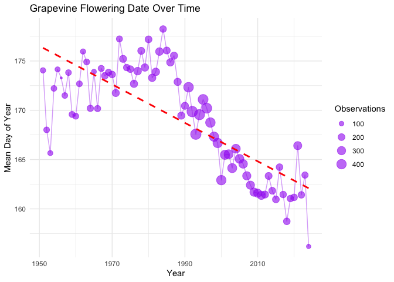

```r
# Step 2: Calculate annual mean DOY
vine_annual <- vine_flowering[, .(
  mean_doy = mean(day, na.rm = TRUE),
  n_obs = .N
), by = year][order(year)]

# Step 3: Plot the trend
p <- ggplot(vine_annual, aes(x = year, y = mean_doy)) +
  geom_point(aes(size = n_obs), color = "purple", alpha = 0.6) +
  geom_line(color = "purple", alpha = 0.4) +
  geom_smooth(method = "lm", color = "red", linetype = 2, se = FALSE) +
  labs(
    title = "Grapevine Flowering Date Over Time",
    x = "Year", y = "Mean Day of Year",
    size = "Observations"
  ) +
  theme_minimal()
print(p)
```

```r
trend <- lm(mean_doy ~ year, data = vine_annual)
slope <- coef(trend)[2]
cat("\nTrend:", round(slope * 10, 2), "days per decade\n")
```

```
#>
#> Trend: -1.95 days per decade
```

**Why grapevine?** *Vitis vinifera* is economically important (wine production), and its phenology is closely monitored. The long historical records make it ideal for studying long-term climate trends.

## Common Pitfalls and Tips

As you start working with phenological data, keep these points in mind:

### Data Quality Matters

- **Always check for outliers**: A flowering date of DOY 300 (late October) for apple is almost certainly an error
- **Consider sample sizes**: Trends from 5 observations are not reliable
- **Check spatial coverage**: Trends might differ between regions

### Species Considerations

- **Check taxonomy**: “Malus” might include multiple apple species
- **Consider subspecies**: Some records have subspecies/variety information
- **Wild vs. cultivated**: Agricultural species may behave differently than wild populations

## Next Steps

Now that you understand the basics, explore the other vignettes for more advanced analyses:

### Phenological Analysis Vignette

Learn to calculate phenological normals (long-term averages), detect anomalies (unusual years), and analyze trends using:

- `pheno_normals()` - Calculate climatological baselines
- `pheno_anomaly()` - Identify deviations from normal
- `pheno_trend_turning()` - Detect changes in trend direction

```r
vignette("phenological-analysis", package = "pep725")
```

### Spatial Phenological Patterns Vignette

Analyze how phenology varies across landscapes:

- `pheno_gradient()` - Quantify elevation and latitude effects
- `pheno_synchrony()` - Measure spatial coherence
- `pheno_map()` - Create maps of phenological patterns

```r
vignette("spatial-patterns", package = "pep725")
```

### Data Quality Assessment Vignette

Ensure your data is reliable and investigate unusual observations:

- `pep_flag_outliers()` - Identify suspicious observations
- `pep_plot_outliers()` - Visualize outliers in context

```r
vignette("data-quality", package = "pep725")
```

## Getting Help

If you encounter problems:

1. **Check the function documentation**: `?function_name` (e.g., `?pheno_normals`)
2. **Read the vignettes**: They contain worked examples
3. **Report issues**: github.com/matthias-da/pep725/issues

## References

Meier, Uwe. 2018. *Growth Stages of Mono- and Dicotyledonous Plants: BBCH Monograph*. Quedlinburg, Germany: Open Agrar Repositorium. https://doi.org/10.5073/20180906-074619.

Templ, Barbara. 2025. “A Roadmap for Advancing Plant Phenological Studies Through Effective Open Research Data Management.” *Ecological Informatics* 87: 103109. https://doi.org/https://doi.org/10.1016/j.ecoinf.2025.103109.

Templ, Barbara, Elisabeth Koch, Kjell Bolmgren, Markus Ungersböck, Anita Paul, Helfried Scheifinger, This Rutishauser, et al. 2018. “Pan European Phenological Database (PEP725): A Single Point of Access for European Data.” *International Journal of Biometeorology* 62: 1109–13. https://doi.org/10.1007/s00484-018-1512-8.

Templ, Barbara, Helfried Scheifinger, Isabella Ostovary, Markus Ungersböck, and Hans Ressl. 2026. “PEP725: 15 Years of Driving European and Global Phenology Science.” *New Phytologist*. https://doi.org/10.1111/nph.70869.

[^1]: University of Applied Sciences Northwestern Switzerland (FHNW)
[^2]: Swiss Federal Institute for Forest, Snow and Landscape Research (WSL)